# Chapter 1

Part B

Sven

2023-09-21

# 1 Tables

Include a table in the RMarkdown document.

Table 1.1: Grading scale applied in this class.

| Percentage | Grade |
| --- | --- |
| 100-98 | A+ |
| 97.9-93 | A |
| 92.9-90 | A- |
| 89.9-88 | B+ |
| 87.9-83 | B |
| 82.9-80 | B- |
| 79.9-78 | C+ |
| 77.9-73 | C |
| 72.9-70 | C- |
| 69.9-68 | D+ |
| 67.9-60 | D |
| 59.9-0 | F |

# 2 Figures

Include a figure in the RMarkdown.

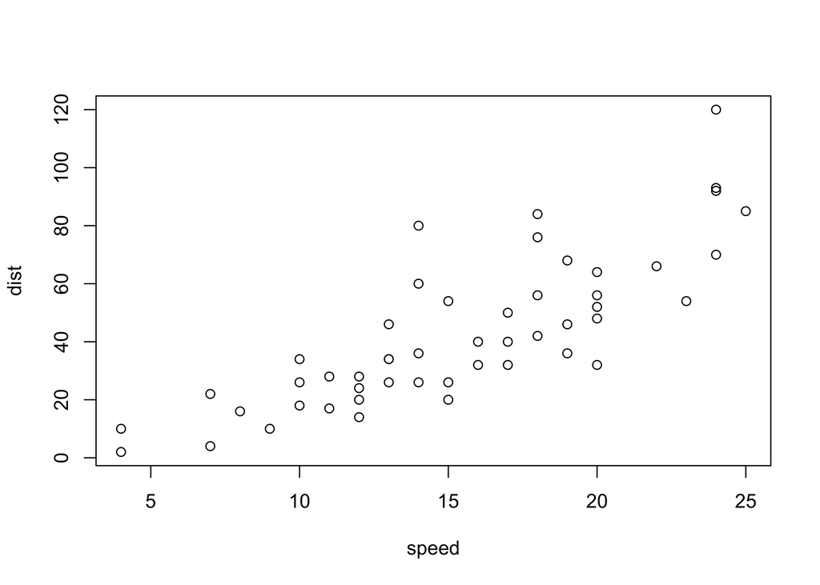

Figure 2.1: Plot of cars’ speed in relation to distance.

# 3 Cross-referencing tables and figures

## 3.1 Tables

See Table 1.1.

## 3.2 Figures

See Figure 2.1.

# 4 Citing publications

## 4.1 Cite in parenthesis

Blah blah (see Baker, 2016 pp. 33–35; also Smith et al., 2016, ch. 1).

## 4.2 Cite in parenthesis without authors

Baker says blah blah (2016).

## 4.3 Cite directly in the text

Baker (2016) says blah.

# 5 References

Baker, M. 2016. 1,500 scientists lift the lid on reproducibility. *Nature* 533: 452–454. Available at: https://doi.org/10.1038/533452a.

Smith, J.F., T.H. Parker, S. Nakagawa, J. Gurevitch, Ecology, and T.(Tools. for T. in Evolution) Working Group. 2016. Promoting transparency in evolutionary biology and ecology. *Systematic Botany* 41: 495–497. Available at: http://www.bioone.org/doi/abs/10.1600/036364416X692262.

# A Appendix 1

Citations of all R packages used to generate this report.

[1] J. Allaire, Y. Xie, J. McPherson, et al. *rmarkdown: Dynamic Documents for R*. R package version 2.16. 2022. https://CRAN.R-project.org/package=rmarkdown.

[2] S. M. Bache and H. Wickham. *magrittr: A Forward-Pipe Operator for R*. R package version 2.0.3. 2022. https://CRAN.R-project.org/package=magrittr.

[3] C. Boettiger. *knitcitations: Citations for Knitr Markdown Files*. R package version 1.0.12. 2021. https://github.com/cboettig/knitcitations.

[4] J. Cheng, C. Sievert, B. Schloerke, et al. *htmltools: Tools for HTML*. R package version 0.5.3. 2022. https://github.com/rstudio/htmltools.

[5] Y. Qiu. *prettydoc: Creating Pretty Documents from R Markdown*. R package version 0.4.1. 2021. https://github.com/yixuan/prettydoc.

[6] R Core Team. *R: A Language and Environment for Statistical Computing*. R Foundation for Statistical Computing. Vienna, Austria, 2022. https://www.R-project.org/.

[7] K. Ren and K. Russell. *formattable: Create Formattable Data Structures*. R package version 0.2.1. 2021. https://CRAN.R-project.org/package=formattable.

[8] H. Wickham, J. Bryan, and M. Barrett. *usethis: Automate Package and Project Setup*. R package version 2.1.6. 2022. https://CRAN.R-project.org/package=usethis.

[9] H. Wickham, R. François, L. Henry, et al. *dplyr: A Grammar of Data Manipulation*. R package version 1.0.9. 2022. https://CRAN.R-project.org/package=dplyr.

[10] H. Wickham, J. Hester, W. Chang, et al. *devtools: Tools to Make Developing R Packages Easier*. R package version 2.4.4. 2022. https://CRAN.R-project.org/package=devtools.

[11] Y. Xie. *bookdown: Authoring Books and Technical Documents with R Markdown*. ISBN 978-1138700109. Boca Raton, Florida: Chapman and Hall/CRC, 2016. https://bookdown.org/yihui/bookdown.

[12] Y. Xie. *bookdown: Authoring Books and Technical Documents with R Markdown*. R package version 0.28. 2022. https://CRAN.R-project.org/package=bookdown.

[13] Y. Xie. *Dynamic Documents with R and knitr*. 2nd. ISBN 978-1498716963. Boca Raton, Florida: Chapman and Hall/CRC, 2015. https://yihui.org/knitr/.

[14] Y. Xie. “knitr: A Comprehensive Tool for Reproducible Research in R”. In: *Implementing Reproducible Computational Research*. Ed. by V. Stodden, F. Leisch and R. D. Peng. ISBN 978-1466561595. Chapman and Hall/CRC, 2014. http://www.crcpress.com/product/isbn/9781466561595.

[15] Y. Xie. *knitr: A General-Purpose Package for Dynamic Report Generation in R*. R package version 1.40. 2022. https://yihui.org/knitr/.

[16] Y. Xie, J. Allaire, and G. Grolemund. *R Markdown: The Definitive Guide*. ISBN 9781138359338. Boca Raton, Florida: Chapman and Hall/CRC, 2018. https://bookdown.org/yihui/rmarkdown.

[17] Y. Xie, C. Dervieux, and E. Riederer. *R Markdown Cookbook*. ISBN 9780367563837. Boca Raton, Florida: Chapman and Hall/CRC, 2020. https://bookdown.org/yihui/rmarkdown-cookbook.

[18] H. Zhu. *kableExtra: Construct Complex Table with kable and Pipe Syntax*. R package version 1.3.4. 2021. https://CRAN.R-project.org/package=kableExtra.

# B Appendix 2

Version information about R, the operating system (OS) and attached or R loaded packages. This appendix was generated using `sessionInfo()`.

[session information not shown]